# A stochastic meta-population model of LSDV epidemics

Thibaut Jombart

## Outline of the work

In this report, we use a stochastic, meta-population SEIRCDV model to simulate outbreaks of Lumpy skin disease virus. We contrast different response scenario:

1. **baseline**: no response
2. **cull_quarant_vacc scenario**: mass culling of infected farms, quarantine (local and ring), ring vaccination
3. **quarant_vacc**: quarantine (local and ring) and vaccination (local and ring)
4. **selcull_quarant_vacc**: selective culling (only individuals in $I$), quarantine (local and ring) and vaccination (local and ring)
5. **selcull_quarant_vacc_insect scenario**: all but mass culling (selective culling, vaccination, quarantine, insecticide)
6. **all**: all measures combined

## Simulation setup

### Required libraries

We load required libraries:

```r
library(tidyverse)
library(viridis)
```

```r
library(qs)
## qs 0.27.3. Announcement: https://github.com/qsbase/qs/issues/103
library(here)
## here() starts at C:/dev/lsdsim
library(digest)
library(compiler)
library(rio)
library(cowplot)
devtools::load_all()
## ℹ Loading lsdsim
```

## Population setting

```r
n_rep <- params$n_rep
duration <- 365
grid_size <- 40
n_pop <- grid_size^2
xy <- make_grid(grid_size)
delta <- make_delta(xy, diffusion = 0.05)
```

The size of the farms, in number of herds, is drawn using an average herd size of 50, exponentially distributed with a minimum at 20 individuals:

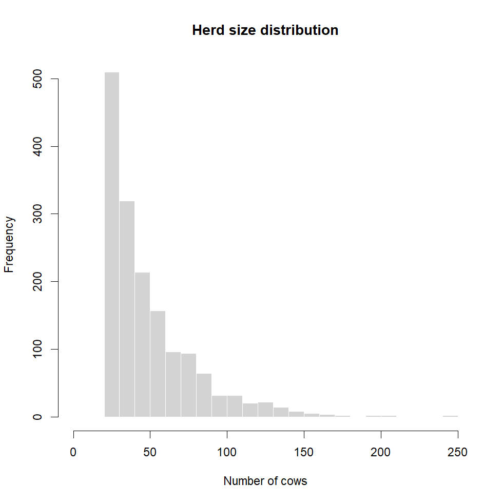

```r
r_herd_size <- function(n) {
  20 + round(rexp(nrow(xy), 1/30))
}

herd_size <- r_herd_size(1e4)
hist(herd_size, border = "white",
     main = "Herd size distribution",
     xlab = "Number of cows",
     nclass = 30,
     xlim = c(0, max(herd_size)))
```

```r
summary(herd_size)
```

```
##    Min. 1st Qu.  Median    Mean 3rd Qu.    Max.
##   20.00   28.00   40.00   49.37   60.25  250.00
```

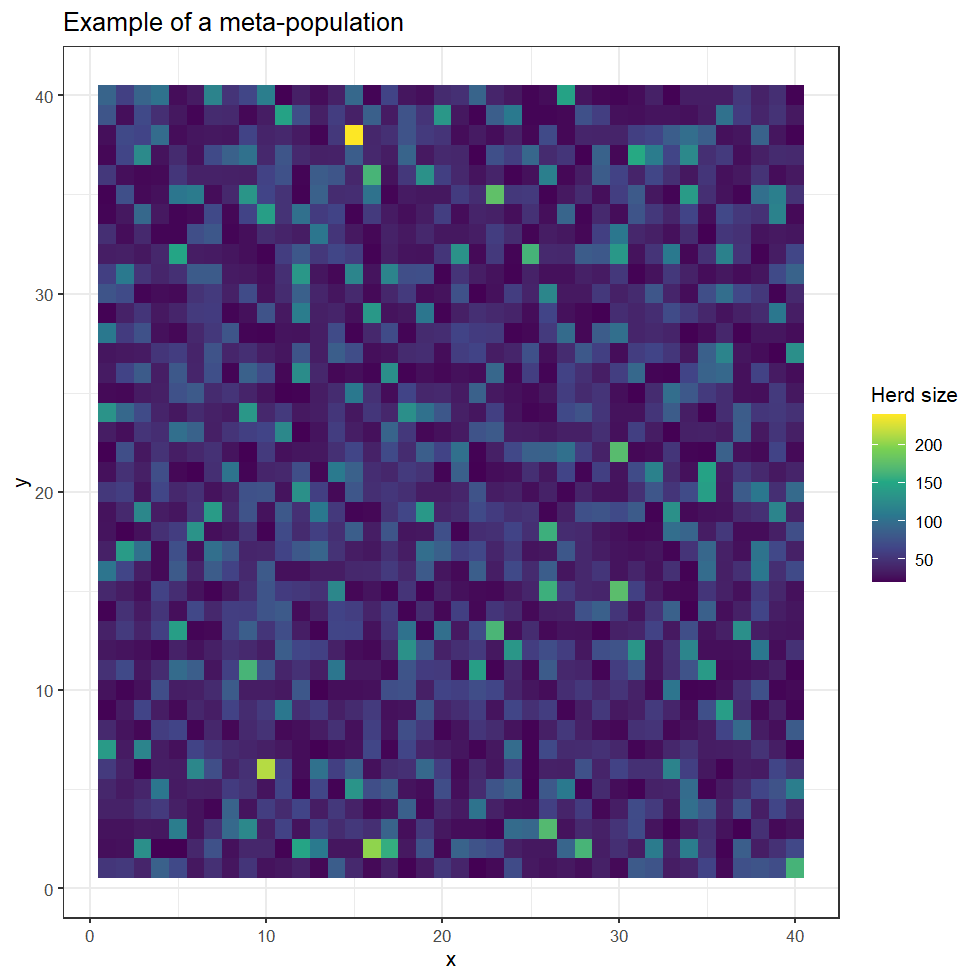

```r
herds <- cbind.data.frame(xy, size = r_herd_size(n_pop))

ggplot(herds, aes(x = x, y = y)) +
  geom_tile(aes(fill = size)) +
  theme_bw() +
  scale_fill_viridis_c("Herd size", n.breaks = 8) +
  labs(title = "Example of a meta-population")
```

In practice, every simulation will use a different population setting (randomly drawn herd sizes).

## Simulations

### General settings

We set the number of replicates, which will apply to each simulation scenario. We also make a compiled version of `lsdsim` and set up initial conditions.

```r
fast_lsdsim <- compiler::cmpfun(lsdsim)
```

This function is used to generate one new case in a randomly chosen population, to seed outbreaks:

```r
r_ini_case <- function(n_pop) {
  out <- rep(0, n_pop)
  out[sample.int(n_pop, 1)] <- 1
  out
}
```

Input parameters will be the same for different interventions:

```r
lsd_params <- rlsd_param(n_rep)
head(lsd_params)
```

```
##       R0_I     R0_A   latent infec_period        cfr    pasymp   beta_I
## 1 20.06279 2.260215 8.179242     9.218572 0.03226814 0.5165882 2.176344
## 2 20.53177 2.226435 8.132146     8.684485 0.03034008 0.5396938 2.364190
## 3 20.45286 1.987613 8.199119     9.080824 0.02265916 0.4746467 2.252313
## 4 19.59250 2.120312 8.785900     8.450591 0.02074281 0.5101052 2.318477
## 5 20.27912 2.211544 8.094693     8.408441 0.02142671 0.4883828 2.411758
## 6 20.22005 1.919365 8.157631     8.900516 0.02150073 0.5053163 2.271784
##      beta_A     sigma     gamma
## 1 0.2451806 0.1222607 0.1084767
## 2 0.2563693 0.1229688 0.1151479
## 3 0.2188803 0.1219643 0.1101222
## 4 0.2509070 0.1138187 0.1183349
## 5 0.2630148 0.1235377 0.1189281
## 6 0.2156465 0.1225846 0.1123530
```

```r
list_herd_size <- lapply(1:n_rep, function(i) r_herd_size(n_pop))
list_ini_cases <- lapply(1:n_rep, function(i) r_ini_case(n_pop))

inputs <- tibble(
  lsd_params,
  ini_S = list_herd_size,
  ini_I = list_ini_cases
)

inputs$label <- apply(inputs, 1, function(e) substr(digest(e), 1, 8))
```

### *baseline* scenario: no response

In these simulations, we use no response.

```r
output_dir <- here::here("outputs", "simulations", "baseline", Sys.Date())
if (!dir.exists(output_dir)) {
  dir.create(output_dir, recursive = TRUE)
}

res_baseline <- vector(mode = "list", length = n_rep)
for (i in seq_len(n_rep)) {
  ## run simulation
  current_sim <- fast_lsdsim(
    grid_size = grid_size,
    time = duration,
    ini_S = unlist(inputs$ini_S[[i]]),
    ini_I = unlist(inputs$ini_I[[i]]),
    delta = delta,
    beta_A = inputs$beta_A[i],
    beta_I = inputs$beta_I[i],
    sigma = inputs$sigma[i],
    gamma = inputs$gamma[i],
    pasymp = inputs$pasymp[i],
    cfr = inputs$cfr[i],
    quarantine = FALSE,
    vaccination = FALSE,
    mass_culling = FALSE,
    select_culling = FALSE,
    insecticide = FALSE
  )

  ## save full simulation to file
  out_file <- file.path(
    output_dir,
    paste0(inputs$label[i], "_baseline", ".qs")
  )
  qsave(current_sim, out_file)

  ## store summary
  res_baseline[[i]] <- summary(current_sim)[duration, ]
}

res_baseline <- cbind(label = inputs$label, bind_rows(res_baseline))
head(res_baseline)
```

```
##      label time     S    E   I   D C     R V     N new_I total_cases        ar
## 1 9bea08f3  365 46688 1593 806 466 0 28289 0 78230    77       14568 0.1862201
## 2 89e594be  365 51082 1188 610 355 0 25034 0 78675    66       12299 0.1563267
## 3 b47d6574  365 35217 1707 995 454 0 39611 0 78363   112       22049 0.2813700
## 4 fb8959f5  365 49558 1319 608 277 0 26475 0 78539    87       13605 0.1732260
## 5 c389f00f  365 40005 1698 829 399 0 36884 0 80231   101       19858 0.2475103
## 6 7622c611  365 54881  743 386 304 0 23167 0 79578    44       12023 0.1510845
##   n_pop_infec n_pop_ever_infec n_naive n_response n_ring total_naive
## 1         181              673    1600          0      0      584000
## 2         141              565    1600          0      0      584000
## 3         237              913    1600          0      0      584000
## 4         153              619    1600          0      0      584000
## 5         198              828    1600          0      0      584000
## 6          94              518    1600          0      0      584000
##   total_response total_ring
## 1              0          0
## 2              0          0
## 3              0          0
## 4              0          0
## 5              0          0
## 6              0          0
```

```r
summary(res_baseline)
```

```
##     label                time           S               E
##  Length:200         Min.   :365   Min.   :32043   Min.   :   0.0
##  Class :character   1st Qu.:365   1st Qu.:44375   1st Qu.: 807.5
##  Mode  :character   Median :365   Median :52295   Median :1086.5
##                     Mean   :365   Mean   :52198   Mean   :1121.2
##                     3rd Qu.:365   3rd Qu.:59037   3rd Qu.:1434.2
##                     Max.   :365   Max.   :82227   Max.   :2172.0
##        I                D                C           R               V
##  Min.   :   0.0   Min.   :   0.0   Min.   :0   Min.   :    1   Min.   :0
##  1st Qu.: 431.8   1st Qu.: 252.8   1st Qu.:0   1st Qu.:19138   1st Qu.:0
##  Median : 586.5   Median : 362.0   Median :0   Median :24586   Median :0
##  Mean   : 597.4   Mean   : 383.5   Mean   :0   Mean   :24861   Mean   :0
##  3rd Qu.: 755.2   3rd Qu.: 488.2   3rd Qu.:0   3rd Qu.:31831   3rd Qu.:0
##  Max.   :1191.0   Max.   :1008.0   Max.   :0   Max.   :43040   Max.   :0
##        N             new_I         total_cases          ar
##  Min.   :76769   Min.   :  0.00   Min.   :    1   Min.   :1.216e-05
##  1st Qu.:78646   1st Qu.: 45.00   1st Qu.: 9974   1st Qu.:1.239e-01
##  Median :79236   Median : 63.50   Median :12786   Median :1.596e-01
##  Mean   :79369   Mean   : 64.88   Mean   :13267   Mean   :1.673e-01
##  3rd Qu.:80082   3rd Qu.: 83.00   3rd Qu.:17144   3rd Qu.:2.160e-01
##  Max.   :83076   Max.   :133.00   Max.   :23966   Max.   :3.026e-01
##   n_pop_infec    n_pop_ever_infec    n_naive       n_response     n_ring
##  Min.   :  0.0   Min.   :  1.0    Min.   :1600   Min.   :0    Min.   :0
##  1st Qu.:100.8   1st Qu.:437.2    1st Qu.:1600   1st Qu.:0    1st Qu.:0
##  Median :134.0   Median :564.0    Median :1600   Median :0    Median :0
##  Mean   :138.8   Mean   :571.7    Mean   :1600   Mean   :0    Mean   :0
##  3rd Qu.:175.0   3rd Qu.:734.8    3rd Qu.:1600   3rd Qu.:0    3rd Qu.:0
##  Max.   :260.0   Max.   :982.0    Max.   :1600   Max.   :0    Max.   :0
##   total_naive     total_response   total_ring
##  Min.   :584000   Min.   :0      Min.   :0
##  1st Qu.:584000   1st Qu.:0      1st Qu.:0
##  Median :584000   Median :0      Median :0
##  Mean   :584000   Mean   :0      Mean   :0
##  3rd Qu.:584000   3rd Qu.:0      3rd Qu.:0
##  Max.   :584000   Max.   :0      Max.   :0
```

```r
qsave(res_baseline, file.path(output_dir, "summary.qs"))
rio::export(res_baseline, file.path(output_dir, "summary.xlsx"))
```

### *cull_quarant_vacc* scenario: mass culling and ring vaccination

In these simulations, we use:

- mass culling of the affected herds
- ring vaccination (i.e. vaccination of neighbours)

```r
output_dir <- here::here("outputs", "simulations", "cull_quarant_vacc", Sys.Date())
if (!dir.exists(output_dir)) {
  dir.create(output_dir, recursive = TRUE)
}

res_cull_quarant_vacc <- vector(mode = "list", length = n_rep)
for (i in seq_len(n_rep)) {
  ## run simulation
  current_sim <- fast_lsdsim(
    grid_size = grid_size,
    time = duration,
    ini_S = unlist(inputs$ini_S[[i]]),
    ini_I = unlist(inputs$ini_I[[i]]),
    delta = delta,
    beta_A = inputs$beta_A[i],
    beta_I = inputs$beta_I[i],
    sigma = inputs$sigma[i],
    gamma = inputs$gamma[i],
    pasymp = inputs$pasymp[i],
    cfr = inputs$cfr[i],
    quarantine = TRUE,
    vaccination = TRUE,
    mass_culling = TRUE,
    select_culling = FALSE,
    insecticide = FALSE,
    interv_delay = 7,
    interv_release = 28,
    quarant_efficacy_in = 0.2,
    quarant_efficacy_out = 0.9,
    vacc_coverage = 1,
    vacc_efficacy = 0.65/21,
    rate_cull = 0.5
  )

  ## save full simulation to file
  out_file <- file.path(
    output_dir,
    paste0(inputs$label[i], "_cull_quarant_vacc", ".qs")
  )
  qsave(current_sim, out_file)

  ## store summary
  res_cull_quarant_vacc[[i]] <- summary(current_sim)[duration, ]
}

res_cull_quarant_vacc <- cbind(label = inputs$label, bind_rows(res_cull_quarant_vacc))
head(res_cull_quarant_vacc)
```

```
##      label time     S E I D   C R   V     N new_I total_cases           ar
## 1 9bea08f3  365 78468 0 0 0 100 0 128 78596     0           3 3.816988e-05
## 2 89e594be  365 78806 0 0 0  92 0 132 78938     0           6 7.600902e-05
## 3 b47d6574  365 78657 0 0 0  31 0 129 78786     0           4 5.077044e-05
## 4 fb8959f5  365 78608 0 0 0 102 0 106 78714     0           1 1.270422e-05
## 5 c389f00f  365 80434 0 0 0  81 0 115 80549     0           3 3.724441e-05
## 6 7622c611  365 79789 0 0 0  26 0  67 79856     0           1 1.252254e-05
##   n_pop_infec n_pop_ever_infec n_naive n_response n_ring total_naive
## 1           0                1    1600          0      0      583840
## 2           0                1    1600          0      0      583840
## 3           0                1    1600          0      0      583840
## 4           0                1    1600          0      0      583850
## 5           0                1    1600          0      0      583830
## 6           0                1    1600          0      0      583885
##   total_response total_ring
## 1             32        128
## 2             32        128
## 3             32        128
## 4             30        120
## 5             34        136
## 6             23         92
```

```r
summary(res_cull_quarant_vacc)
```

```
##     label                time           S               E           I
##  Length:200         Min.   :365   Min.   :76722   Min.   :0   Min.   :0
##  Class :character   1st Qu.:365   1st Qu.:78751   1st Qu.:0   1st Qu.:0
##  Mode  :character   Median :365   Median :79407   Median :0   Median :0
##                     Mean   :365   Mean   :79505   Mean   :0   Mean   :0
##                     3rd Qu.:365   3rd Qu.:80133   3rd Qu.:0   3rd Qu.:0
##                     Max.   :365   Max.   :83358   Max.   :0   Max.   :0
##        D              C                R              V
##  Min.   :0.00   Min.   : 21.00   Min.   :0.00   Min.   : 51.00
##  1st Qu.:0.00   1st Qu.: 45.00   1st Qu.:0.00   1st Qu.: 99.75
##  Median :0.00   Median : 73.00   Median :0.00   Median :140.00
##  Mean   :0.05   Mean   : 96.41   Mean   :0.47   Mean   :151.09
##  3rd Qu.:0.00   3rd Qu.:126.75   3rd Qu.:1.00   3rd Qu.:186.25
##  Max.   :2.00   Max.   :412.00   Max.   :5.00   Max.   :437.00
##        N             new_I    total_cases           ar             n_pop_infec
##  Min.   :77040   Min.   :0   Min.   : 1.000   Min.   :1.209e-05   Min.   :0
##  1st Qu.:78908   1st Qu.:0   1st Qu.: 2.000   1st Qu.:2.538e-05   1st Qu.:0
##  Median :79587   Median :0   Median : 4.000   Median :5.044e-05   Median :0
##  Mean   :79656   Mean   :0   Mean   : 4.905   Mean   :6.165e-05   Mean   :0
##  3rd Qu.:80298   3rd Qu.:0   3rd Qu.: 7.000   3rd Qu.:8.762e-05   3rd Qu.:0
##  Max.   :83466   Max.   :0   Max.   :17.000   Max.   :2.115e-04   Max.   :0
##  n_pop_ever_infec    n_naive       n_response     n_ring   total_naive
##  Min.   :1.00     Min.   :1600   Min.   :0    Min.   :0   Min.   :583265
##  1st Qu.:1.00     1st Qu.:1600   1st Qu.:0    1st Qu.:0   1st Qu.:583715
##  Median :1.00     Median :1600   Median :0    Median :0   Median :583823
##  Mean   :1.72     Mean   :1600   Mean   :0    Mean   :0   Mean   :583774
##  3rd Qu.:2.00     3rd Qu.:1600   3rd Qu.:0    3rd Qu.:0   3rd Qu.:583855
##  Max.   :6.00     Max.   :1600   Max.   :0    Max.   :0   Max.   :583904
##  total_response     total_ring
##  Min.   : 23.00   Min.   : 72.0
##  1st Qu.: 30.75   1st Qu.:116.0
##  Median : 36.00   Median :142.0
##  Mean   : 52.53   Mean   :173.8
##  3rd Qu.: 64.00   3rd Qu.:216.5
##  Max.   :189.00   Max.   :551.0
```

```r
qsave(res_cull_quarant_vacc, file.path(output_dir, "summary.qs"))
rio::export(res_cull_quarant_vacc, file.path(output_dir, "summary.xlsx"))
```

### *quarant_vacc* scenario: quarantine and ring vaccination

In these simulations, we use:

- quarantine of infected herds and neighbours
- vaccination of infected herds and neighbours

```r
output_dir <- here::here("outputs", "simulations", "quarant_vacc", Sys.Date())
if (!dir.exists(output_dir)) {
  dir.create(output_dir, recursive = TRUE)
}

res_quarant_vacc <- vector(mode = "list", length = n_rep)
for (i in seq_len(n_rep)) {
  ## run simulation
  current_sim <- fast_lsdsim(
    grid_size = grid_size,
    time = duration,
    ini_S = unlist(inputs$ini_S[[i]]),
    ini_I = unlist(inputs$ini_I[[i]]),
    delta = delta,
    beta_A = inputs$beta_A[i],
    beta_I = inputs$beta_I[i],
    sigma = inputs$sigma[i],
    gamma = inputs$gamma[i],
    pasymp = inputs$pasymp[i],
    cfr = inputs$cfr[i],
    quarantine = TRUE,
    vaccination = TRUE,
    mass_culling = FALSE,
    select_culling = FALSE,
    insecticide = FALSE,
    interv_delay = 7,
    interv_release = 28,
    quarant_efficacy_in = 0.2,
    quarant_efficacy_out = 0.9,
    vacc_coverage = 1,
    vacc_efficacy = 0.65/21
  )

  ## save full simulation to file
  out_file <- file.path(
    output_dir,
    paste0(inputs$label[i], "_quarant_vacc", ".qs")
  )
  qsave(current_sim, out_file)

  ## store summary
  res_quarant_vacc[[i]] <- summary(current_sim)[duration, ]
}

res_quarant_vacc <- cbind(label = inputs$label, bind_rows(res_quarant_vacc))
head(res_quarant_vacc)
```

```
##      label time     S E I D C   R   V     N new_I total_cases           ar
## 1 9bea08f3  365 78428 0 0 1 0  19 248 78695     0           6 7.624373e-05
## 2 89e594be  365 78429 0 0 7 0 138 456 79023     0          77 9.743999e-04
## 3 b47d6574  365 78609 0 0 0 0  30 178 78817     0          18 2.283771e-04
## 4 fb8959f5  365 78536 0 0 1 0  65 214 78815     0          28 3.552623e-04
## 5 c389f00f  365 80388 0 0 1 0  48 193 80629     0          24 2.976597e-04
## 6 7622c611  365 79730 0 0 1 0  26 125 79881     0          16 2.002979e-04
##   n_pop_infec n_pop_ever_infec n_naive n_response n_ring total_naive
## 1           0                1    1600          0      0      583640
## 2           0                5    1600          0      0      582618
## 3           0                1    1600          0      0      583615
## 4           0                1    1600          0      0      583425
## 5           0                1    1600          0      0      583590
## 6           0                1    1600          0      0      583640
##   total_response total_ring
## 1             72        288
## 2            362       1020
## 3             77        308
## 4            115        460
## 5             82        328
## 6             72        288
```

```r
summary(res_quarant_vacc)
```

```
##     label                time           S               E           I
##  Length:200         Min.   :365   Min.   :76583   Min.   :0   Min.   :0
##  Class :character   1st Qu.:365   1st Qu.:78501   1st Qu.:0   1st Qu.:0
##  Mode  :character   Median :365   Median :79231   Median :0   Median :0
##                     Mean   :365   Mean   :79287   Mean   :0   Mean   :0
##                     3rd Qu.:365   3rd Qu.:79939   3rd Qu.:0   3rd Qu.:0
##                     Max.   :365   Max.   :83043   Max.   :0   Max.   :0
##        D                C           R                V                N
##  Min.   : 0.000   Min.   :0   Min.   :  1.00   Min.   :  90.0   Min.   :77255
##  1st Qu.: 0.000   1st Qu.:0   1st Qu.: 41.00   1st Qu.: 190.2   1st Qu.:79007
##  Median : 1.000   Median :0   Median : 72.00   Median : 328.0   Median :79676
##  Mean   : 1.325   Mean   :0   Mean   : 88.36   Mean   : 375.4   Mean   :79751
##  3rd Qu.: 2.000   3rd Qu.:0   3rd Qu.:120.50   3rd Qu.: 484.2   3rd Qu.:80471
##  Max.   :11.000   Max.   :0   Max.   :382.00   Max.   :1521.0   Max.   :83512
##      new_I    total_cases          ar             n_pop_infec n_pop_ever_infec
##  Min.   :0   Min.   :  1.0   Min.   :1.238e-05   Min.   :0    Min.   : 1.000
##  1st Qu.:0   1st Qu.: 19.0   1st Qu.:2.405e-04   1st Qu.:0    1st Qu.: 1.000
##  Median :0   Median : 35.5   Median :4.520e-04   Median :0    Median : 2.500
##  Mean   :0   Mean   : 45.0   Mean   :5.642e-04   Mean   :0    Mean   : 3.135
##  3rd Qu.:0   3rd Qu.: 60.0   3rd Qu.:7.511e-04   3rd Qu.:0    3rd Qu.: 4.000
##  Max.   :0   Max.   :200.0   Max.   :2.514e-03   Max.   :0    Max.   :14.000
##     n_naive       n_response     n_ring   total_naive     total_response
##  Min.   :1600   Min.   :0    Min.   :0   Min.   :580566   Min.   :  23.0
##  1st Qu.:1600   1st Qu.:0    1st Qu.:0   1st Qu.:582886   1st Qu.:  88.5
##  Median :1600   Median :0    Median :0   Median :583273   Median : 172.5
##  Mean   :1600   Mean   :0    Mean   :0   Mean   :583138   Mean   : 228.3
##  3rd Qu.:1600   3rd Qu.:0    3rd Qu.:0   3rd Qu.:583572   3rd Qu.: 306.0
##  Max.   :1600   Max.   :0    Max.   :0   Max.   :583885   Max.   :1072.0
##    total_ring
##  Min.   :  92.0
##  1st Qu.: 336.0
##  Median : 543.0
##  Mean   : 633.7
##  3rd Qu.: 815.5
##  Max.   :2362.0
```

```r
qsave(res_quarant_vacc, file.path(output_dir, "summary.qs"))
rio::export(res_quarant_vacc, file.path(output_dir, "summary.xlsx"))
```

### *selcull_quarant_vacc* scenario: selective culling, quarantine and ring vaccination

In these simulations, we use:

- selective culling of infected individuals
- quarantine of infected herds and neighbours
- vaccination of infected herds and neighbours

```r
output_dir <- here::here("outputs", "simulations", "quarant_vacc", Sys.Date())
if (!dir.exists(output_dir)) {
  dir.create(output_dir, recursive = TRUE)
}

res_selcull_quarant_vacc <- vector(mode = "list", length = n_rep)
for (i in seq_len(n_rep)) {
  ## run simulation
  current_sim <- fast_lsdsim(
    grid_size = grid_size,
    time = duration,
    ini_S = unlist(inputs$ini_S[[i]]),
    ini_I = unlist(inputs$ini_I[[i]]),
    delta = delta,
    beta_A = inputs$beta_A[i],
    beta_I = inputs$beta_I[i],
    sigma = inputs$sigma[i],
    gamma = inputs$gamma[i],
    pasymp = inputs$pasymp[i],
    cfr = inputs$cfr[i],
    quarantine = TRUE,
    vaccination = TRUE,
    mass_culling = FALSE,
    select_culling = TRUE,
    insecticide = FALSE,
    interv_delay = 7,
    interv_release = 28,
    quarant_efficacy_in = 0.2,
    quarant_efficacy_out = 0.9,
    vacc_coverage = 1,
    vacc_efficacy = 0.65/21,
    rate_cull = 1e30 # immediate culling
  )

  ## save full simulation to file
  out_file <- file.path(
    output_dir,
    paste0(inputs$label[i], "_selcull_quarant_vacc", ".qs")
  )
  qsave(current_sim, out_file)

  ## store summary
  res_selcull_quarant_vacc [[i]] <- summary(current_sim)[duration, ]
}

res_selcull_quarant_vacc  <- cbind(
  label = inputs$label,
  bind_rows(res_selcull_quarant_vacc )
)

head(res_selcull_quarant_vacc )
```

```
##      label time     S E I D  C  R   V     N new_I total_cases           ar
## 1 9bea08f3  365 78418 0 0 0 24 21 233 78672     0          24 0.0003050641
## 2 89e594be  365 78765 0 0 0  8  9 248 79022     0           9 0.0001138923
## 3 b47d6574  365 78611 0 0 0 16  8 182 78801     0          16 0.0002030431
## 4 fb8959f5  365 78557 0 0 0 19 31 209 78797     0          19 0.0002411259
## 5 c389f00f  365 80181 0 0 0 37 27 385 80593     0          38 0.0004715050
## 6 7622c611  365 79530 0 0 0 25 30 297 79857     0          27 0.0003381044
##   n_pop_infec n_pop_ever_infec n_naive n_response n_ring total_naive
## 1           0                1    1600          0      0      583575
## 2           0                1    1600          0      0      583715
## 3           0                1    1600          0      0      583600
## 4           0                1    1600          0      0      583670
## 5           0                2    1600          0      0      583580
## 6           0                3    1600          0      0      583256
##   total_response total_ring
## 1             85        340
## 2             57        228
## 3             80        320
## 4             66        264
## 5            100        320
## 6            189        555
```

```r
summary(res_selcull_quarant_vacc)
```

```
##     label                time           S               E           I
##  Length:200         Min.   :365   Min.   :76480   Min.   :0   Min.   :0
##  Class :character   1st Qu.:365   1st Qu.:78602   1st Qu.:0   1st Qu.:0
##  Mode  :character   Median :365   Median :79297   Median :0   Median :0
##                     Mean   :365   Mean   :79402   Mean   :0   Mean   :0
##                     3rd Qu.:365   3rd Qu.:80040   3rd Qu.:0   3rd Qu.:0
##                     Max.   :365   Max.   :83136   Max.   :0   Max.   :0
##        D              C                R               V
##  Min.   :0.00   Min.   :  0.00   Min.   : 1.00   Min.   :  72.0
##  1st Qu.:0.00   1st Qu.: 10.75   1st Qu.:12.00   1st Qu.: 181.8
##  Median :0.00   Median : 18.00   Median :19.00   Median : 248.0
##  Mean   :0.05   Mean   : 20.49   Mean   :22.61   Mean   : 307.8
##  3rd Qu.:0.00   3rd Qu.: 26.25   3rd Qu.:30.00   3rd Qu.: 412.0
##  Max.   :1.00   Max.   :113.00   Max.   :97.00   Max.   :1136.0
##        N             new_I    total_cases           ar             n_pop_infec
##  Min.   :77185   Min.   :0   Min.   :  1.00   Min.   :0.0000122   Min.   :0
##  1st Qu.:78986   1st Qu.:0   1st Qu.: 11.00   1st Qu.:0.0001407   1st Qu.:0
##  Median :79650   Median :0   Median : 19.00   Median :0.0002387   Median :0
##  Mean   :79732   Mean   :0   Mean   : 21.95   Mean   :0.0002752   Mean   :0
##  3rd Qu.:80456   3rd Qu.:0   3rd Qu.: 28.00   3rd Qu.:0.0003488   3rd Qu.:0
##  Max.   :83493   Max.   :0   Max.   :118.00   Max.   :0.0014651   Max.   :0
##  n_pop_ever_infec    n_naive       n_response     n_ring   total_naive
##  Min.   : 1.000   Min.   :1600   Min.   :0    Min.   :0   Min.   :581731
##  1st Qu.: 1.000   1st Qu.:1600   1st Qu.:0    1st Qu.:0   1st Qu.:583329
##  Median : 2.000   Median :1600   Median :0    Median :0   Median :583570
##  Mean   : 2.245   Mean   :1600   Mean   :0    Mean   :0   Mean   :583477
##  3rd Qu.: 3.000   3rd Qu.:1600   3rd Qu.:0    3rd Qu.:0   3rd Qu.:583671
##  Max.   :11.000   Max.   :1600   Max.   :0    Max.   :0   Max.   :583908
##  total_response    total_ring
##  Min.   : 23.0   Min.   :  69.0
##  1st Qu.: 66.0   1st Qu.: 260.0
##  Median : 98.0   Median : 336.0
##  Mean   :128.7   Mean   : 394.4
##  3rd Qu.:180.0   3rd Qu.: 498.5
##  Max.   :701.0   Max.   :1568.0
```

```r
qsave(res_selcull_quarant_vacc, file.path(output_dir, "summary.qs"))
rio::export(res_selcull_quarant_vacc, file.path(output_dir, "summary.xlsx"))
```

### *selcull_quarant_vacc_insect* scenario: selective culling, quarantine, ring vaccination, insecticide (all but mass culling)

In these simulations, we use:

- selective culling of infected individuals
- quarantine of infected herds and neighbours
- vaccination of infected herds and neighbours
- insecticide spray of infected herds and neighbours

```r
output_dir <- here::here("outputs", "simulations", "selcull_quarant_vacc_insect", Sys.Date())
if (!dir.exists(output_dir)) {
  dir.create(output_dir, recursive = TRUE)
}

res_selcull_quarant_vacc_insect <- vector(mode = "list", length = n_rep)
for (i in seq_len(n_rep)) {
  ## run simulation
  current_sim <- fast_lsdsim(
    grid_size = grid_size,
    time = duration,
    ini_S = unlist(inputs$ini_S[[i]]),
    ini_I = unlist(inputs$ini_I[[i]]),
    delta = delta,
    beta_A = inputs$beta_A[i],
    beta_I = inputs$beta_I[i],
    sigma = inputs$sigma[i],
    gamma = inputs$gamma[i],
    pasymp = inputs$pasymp[i],
    cfr = inputs$cfr[i],
    quarantine = TRUE,
    vaccination = TRUE,
    mass_culling = FALSE,
    select_culling = TRUE,
    insecticide = TRUE,
    interv_delay = 7,
    interv_release = 28,
    vacc_coverage = 1,
    vacc_efficacy = 0.65/21,
    quarant_efficacy_in = 0.2,
    quarant_efficacy_out = 0.9,
    rate_cull = 1e30,
    insect_efficacy = 0.5
  )

  ## save full simulation to file
  out_file <- file.path(
    output_dir,
    paste0(inputs$label[i], "_selcull_quarant_vacc_insect", ".qs")
  )
  qsave(current_sim, out_file)

  ## store summary
  res_selcull_quarant_vacc_insect[[i]] <- summary(current_sim)[duration, ]
}

res_selcull_quarant_vacc_insect <- cbind(label = inputs$label, bind_rows(res_selcull_quarant_vacc_insect))
head(res_selcull_quarant_vacc_insect)
```

```
##      label time     S E I D  C  R   V     N new_I total_cases           ar
## 1 9bea08f3  365 78355 0 0 0 14 12 315 78682     0          14 0.0001779314
## 2 89e594be  365 78788 0 0 0 15 11 216 79015     0          15 0.0001898374
## 3 b47d6574  365 78433 0 0 0 12 13 359 78805     0          14 0.0001776537
## 4 fb8959f5  365 78440 0 0 0 20 23 333 78796     0          21 0.0002665110
## 5 c389f00f  365 80420 0 0 0 11 16 183 80619     0          11 0.0001364443
## 6 7622c611  365 79549 0 0 0 31 33 269 79851     0          33 0.0004132697
##   n_pop_infec n_pop_ever_infec n_naive n_response n_ring total_naive
## 1           0                2    1600          0      0      583596
## 2           0                1    1600          0      0      583750
## 3           0                3    1600          0      0      583522
## 4           0                2    1600          0      0      583512
## 5           0                1    1600          0      0      583735
## 6           0                3    1600          0      0      583332
##   total_response total_ring
## 1             94        310
## 2             50        200
## 3            120        358
## 4            112        376
## 5             53        212
## 6            142        526
```

```r
summary(res_selcull_quarant_vacc_insect)
```

```
##     label                time           S               E           I
##  Length:200         Min.   :365   Min.   :76931   Min.   :0   Min.   :0
##  Class :character   1st Qu.:365   1st Qu.:78717   1st Qu.:0   1st Qu.:0
##  Mode  :character   Median :365   Median :79411   Median :0   Median :0
##                     Mean   :365   Mean   :79477   Mean   :0   Mean   :0
##                     3rd Qu.:365   3rd Qu.:80121   3rd Qu.:0   3rd Qu.:0
##                     Max.   :365   Max.   :83285   Max.   :0   Max.   :0
##        D               C               R               V
##  Min.   :0.000   Min.   : 0.00   Min.   : 0.00   Min.   : 73.0
##  1st Qu.:0.000   1st Qu.: 7.00   1st Qu.: 7.00   1st Qu.:180.0
##  Median :0.000   Median :11.00   Median :12.00   Median :235.5
##  Mean   :0.035   Mean   :11.84   Mean   :12.73   Mean   :251.1
##  3rd Qu.:0.000   3rd Qu.:16.00   3rd Qu.:17.00   3rd Qu.:304.5
##  Max.   :1.000   Max.   :43.00   Max.   :35.00   Max.   :759.0
##        N             new_I    total_cases          ar             n_pop_infec
##  Min.   :77248   Min.   :0   Min.   : 1.00   Min.   :1.219e-05   Min.   :0
##  1st Qu.:78987   1st Qu.:0   1st Qu.: 8.00   1st Qu.:1.014e-04   1st Qu.:0
##  Median :79656   Median :0   Median :12.00   Median :1.508e-04   Median :0
##  Mean   :79741   Mean   :0   Mean   :13.01   Mean   :1.631e-04   Mean   :0
##  3rd Qu.:80464   3rd Qu.:0   3rd Qu.:16.25   3rd Qu.:2.080e-04   3rd Qu.:0
##  Max.   :83496   Max.   :0   Max.   :45.00   Max.   :5.642e-04   Max.   :0
##  n_pop_ever_infec    n_naive       n_response     n_ring   total_naive
##  Min.   :1.000    Min.   :1600   Min.   :0    Min.   :0   Min.   :583089
##  1st Qu.:1.000    1st Qu.:1600   1st Qu.:0    1st Qu.:0   1st Qu.:583523
##  Median :1.000    Median :1600   Median :0    Median :0   Median :583635
##  Mean   :1.715    Mean   :1600   Mean   :0    Mean   :0   Mean   :583614
##  3rd Qu.:2.000    3rd Qu.:1600   3rd Qu.:0    3rd Qu.:0   3rd Qu.:583734
##  Max.   :6.000    Max.   :1600   Max.   :0    Max.   :0   Max.   :583885
##  total_response     total_ring
##  Min.   : 23.00   Min.   : 92.0
##  1st Qu.: 54.00   1st Qu.:212.0
##  Median : 77.50   Median :280.0
##  Mean   : 89.43   Mean   :296.9
##  3rd Qu.:112.25   3rd Qu.:364.5
##  Max.   :269.00   Max.   :674.0
```

```r
qsave(res_selcull_quarant_vacc_insect, file.path(output_dir, "summary.qs"))
rio::export(res_selcull_quarant_vacc_insect, file.path(output_dir, "summary.xlsx"))
```

### all scenario: mass culling, quarantine, ring vaccination, insecticide

In these simulations, we use mass culling, ring quarantine and vaccination, and insecticide spray.

```r
output_dir <- here::here("outputs", "simulations", "all", Sys.Date())
if (!dir.exists(output_dir)) {
  dir.create(output_dir, recursive = TRUE)
}

res_all <- vector(mode = "list", length = n_rep)
for (i in seq_len(n_rep)) {
  ## run simulation
  current_sim <- fast_lsdsim(
    grid_size = grid_size,
    time = duration,
    ini_S = unlist(inputs$ini_S[[i]]),
    ini_I = unlist(inputs$ini_I[[i]]),
    delta = delta,
    beta_A = inputs$beta_A[i],
    beta_I = inputs$beta_I[i],
    sigma = inputs$sigma[i],
    gamma = inputs$gamma[i],
    pasymp = inputs$pasymp[i],
    cfr = inputs$cfr[i],
    quarantine = TRUE,
    vaccination = TRUE,
    mass_culling = TRUE,
    select_culling = TRUE, # redundant with mass culling but for consistency
    insecticide = TRUE,
    interv_delay = 7,
    interv_release = 28,
    vacc_coverage = 1,
    vacc_efficacy = 0.65/21,
    rate_cull = 0.5,
    quarant_efficacy_in = 0.2,
    quarant_efficacy_out = 0.9,
    insect_efficacy = 0.5
  )

  ## save full simulation to file
  out_file <- file.path(
    output_dir,
    paste0(inputs$label[i], "_all", ".qs")
  )
  qsave(current_sim, out_file)

  ## store summary
  res_all[[i]] <- summary(current_sim)[duration, ]
}

res_all <- cbind(label = inputs$label, bind_rows(res_all))
head(res_all)
```

```
##      label time     S E I D   C R   V     N new_I total_cases           ar
## 1 9bea08f3  365 78478 0 0 0 100 1 117 78596     0           8 1.017864e-04
## 2 89e594be  365 78682 0 0 0 206 0 142 78824     0           6 7.611895e-05
## 3 b47d6574  365 78682 0 0 0  31 0 104 78786     0           1 1.269261e-05
## 4 fb8959f5  365 78575 0 0 0 102 1 138 78714     0           7 8.892954e-05
## 5 c389f00f  365 80447 0 0 0  81 0 102 80549     0           2 2.482961e-05
## 6 7622c611  365 79765 0 0 0  26 0  91 79856     0           2 2.504508e-05
##   n_pop_infec n_pop_ever_infec n_naive n_response n_ring total_naive
## 1           0                1    1600          0      0      583850
## 2           0                2    1600          0      0      583761
## 3           0                1    1600          0      0      583875
## 4           0                1    1600          0      0      583805
## 5           0                1    1600          0      0      583850
## 6           0                1    1600          0      0      583840
##   total_response total_ring
## 1             30        120
## 2             57        182
## 3             25        100
## 4             39        156
## 5             30        120
## 6             32        128
```

```r
summary(res_all)
```

```
##     label                time           S               E           I
##  Length:200         Min.   :365   Min.   :76846   Min.   :0   Min.   :0
##  Class :character   1st Qu.:365   1st Qu.:78766   1st Qu.:0   1st Qu.:0
##  Mode  :character   Median :365   Median :79440   Median :0   Median :0
##                     Mean   :365   Mean   :79522   Mean   :0   Mean   :0
##                     3rd Qu.:365   3rd Qu.:80193   3rd Qu.:0   3rd Qu.:0
##                     Max.   :365   Max.   :83351   Max.   :0   Max.   :0
##        D               C                R               V
##  Min.   :0.000   Min.   : 21.00   Min.   :0.000   Min.   : 45.0
##  1st Qu.:0.000   1st Qu.: 43.00   1st Qu.:0.000   1st Qu.:102.8
##  Median :0.000   Median : 71.00   Median :0.000   Median :130.0
##  Mean   :0.045   Mean   : 88.22   Mean   :0.485   Mean   :141.3
##  3rd Qu.:0.000   3rd Qu.:123.50   3rd Qu.:1.000   3rd Qu.:167.2
##  Max.   :2.000   Max.   :346.00   Max.   :5.000   Max.   :382.0
##        N             new_I    total_cases          ar             n_pop_infec
##  Min.   :77099   Min.   :0   Min.   : 1.00   Min.   :1.233e-05   Min.   :0
##  1st Qu.:78919   1st Qu.:0   1st Qu.: 2.00   1st Qu.:2.545e-05   1st Qu.:0
##  Median :79581   Median :0   Median : 4.00   Median :4.946e-05   Median :0
##  Mean   :79664   Mean   :0   Mean   : 4.09   Mean   :5.135e-05   Mean   :0
##  3rd Qu.:80391   3rd Qu.:0   3rd Qu.: 5.00   3rd Qu.:6.325e-05   3rd Qu.:0
##  Max.   :83466   Max.   :0   Max.   :17.00   Max.   :2.087e-04   Max.   :0
##  n_pop_ever_infec    n_naive       n_response     n_ring   total_naive
##  Min.   :1.00     Min.   :1600   Min.   :0    Min.   :0   Min.   :583574
##  1st Qu.:1.00     1st Qu.:1600   1st Qu.:0    1st Qu.:0   1st Qu.:583742
##  Median :1.00     Median :1600   Median :0    Median :0   Median :583835
##  Mean   :1.54     Mean   :1600   Mean   :0    Mean   :0   Mean   :583796
##  3rd Qu.:2.00     3rd Qu.:1600   3rd Qu.:0    3rd Qu.:0   3rd Qu.:583850
##  Max.   :4.00     Max.   :1600   Max.   :0    Max.   :0   Max.   :583908
##  total_response    total_ring
##  Min.   : 23.0   Min.   : 69.0
##  1st Qu.: 30.0   1st Qu.:120.0
##  Median : 34.0   Median :132.0
##  Mean   : 46.1   Mean   :158.0
##  3rd Qu.: 60.0   3rd Qu.:198.5
##  Max.   :119.0   Max.   :312.0
```

```r
qsave(res_all, file.path(output_dir, "summary.qs"))
rio::export(res_all, file.path(output_dir, "summary.xlsx"))
```

## Analyses

```r
res_baseline$scenario <- "baseline"
res_cull_quarant_vacc$scenario <- "cull_quarant_vacc"
res_quarant_vacc$scenario <- "quarant_vacc"
res_selcull_quarant_vacc$scenario <- "selcull_quarant_vacc"
res_selcull_quarant_vacc_insect$scenario <- "selcull_quarant_vacc_insect"
res_all$scenario <- "all"

res <- bind_rows(
  res_baseline,
  res_cull_quarant_vacc,
  res_quarant_vacc,
  res_selcull_quarant_vacc,
  res_selcull_quarant_vacc_insect,
  res_all
  ) %>%
  select(scenario, everything()) %>%
  mutate(
    p_immun = (R + V) / N,
    p_dead = (D + C) / (N + D + C),
    scenario = factor(
      scenario, levels = c(
        "baseline",
        "cull_quarant_vacc",
        "quarant_vacc",
        "selcull_quarant_vacc",
        "selcull_quarant_vacc_insect",
        "all")
      )
  )

file_name <- paste0("res_", Sys.Date(), ".qs")
qsave(res, here::here("outputs", file_name))
```

This is evaluated only if new results have not been obtained, fetching the latest version of the results:

```r
all_files <- list.files(here::here("outputs"), pattern = "^res")
extract_date <- function(x) {
  out <- gsub("[^[:digit:]-]", "", x)
  as.Date(out)
}
dates <- sapply(all_files, extract_date)
to_keep <- which.max(dates)
file_to_keep <- all_files[to_keep]
file_to_keep
message("reading results from file:", file_to_keep)
res <- qread(here::here("outputs", file_to_keep))
```

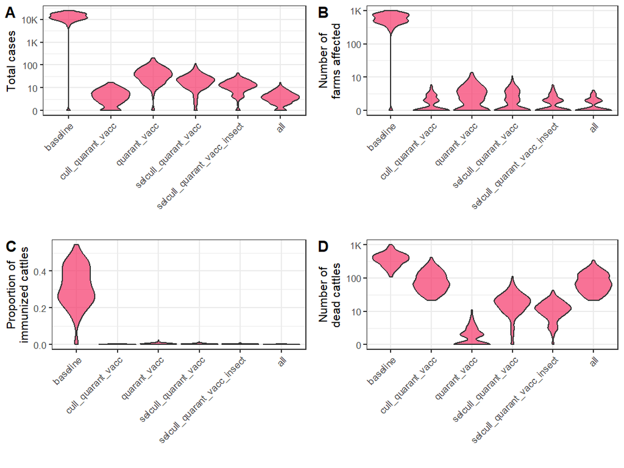

```r
label_numbers <- function(x, show_1_as_0 = FALSE) {
  out <- scales::label_number(scale_cut = scales::cut_long_scale())(x)
  if (show_1_as_0) {
    out[out=="1"] <- "0"
  }
  out
}

p_cases <- ggplot(res, aes(x = scenario, y = total_cases)) +
  geom_violin(scale = "width", fill = "#F5275E", alpha = 0.65) +
  scale_y_continuous(
    transform = "log10",
    labels = function(e) label_numbers(e, show_1_as_0 = TRUE)
  ) +
  theme_bw() +
  labs(
    x = "",
    y = "Total cases"
  )

p_n_pop <- ggplot(res, aes(x = scenario, y = n_pop_ever_infec)) +
  geom_violin(scale = "width", fill = "#F5275E", alpha = 0.65) +
  scale_y_continuous(
    transform = "log10",
    labels = function(e) label_numbers(e, show_1_as_0 = TRUE)
  ) +
  theme_bw() +
  labs(
    x = "",
    y = "Number of\nfarms affected"
    )


p_immun <- ggplot(res, aes(x = scenario, y = p_immun)) +
  geom_violin(scale = "width", fill = "#F5275E", alpha = 0.65) +
  theme_bw() +
  labs(
    x = "",
    y = "Proportion of\nimmunized cattles"
    )

p_dead <- ggplot(res, aes(x = scenario, y = (D+C))) +
  geom_violin(scale = "width", fill = "#F5275E", alpha = 0.65) +
  scale_y_continuous(
    transform = "log10",
    labels = function(e) label_numbers(e, show_1_as_0 = TRUE)
  ) +
  theme_bw() +
  labs(
    x = "",
    y = "Number of\ndead cattles"
  )

rotated_x <- theme(
  axis.text.x = element_text(angle = 45, vjust = 1, hjust=1)
  )

plot_grid(
  p_cases + rotated_x,
  p_n_pop + rotated_x,
  p_immun + rotated_x,
  p_dead + rotated_x,
  labels = LETTERS[1:4]
)
```

Some summary statistics:

```r
# f_smry <- function(x) {
#   out <- c(
#     mean = mean(x),
#     median = median(x),
#     CI_95 = sprintf("[%f;%f]",
#                     quantile(x, 0.025),
#                     quantile(x, 0.975)
#                     )
#   )
# }

# total cases
res %>%
  group_by(scenario) %>%
  summarise(
    mean_cases = mean(total_cases) %>% label_numbers(),
    median_cases = median(total_cases) %>% label_numbers(),
    cases_0.025 = quantile(total_cases, 0.025) %>% label_numbers(),
    cases_0.975 = quantile(total_cases, 0.975) %>% label_numbers(),
    p_greater_100_cases = mean(total_cases >= 100)
  ) %>%
  knitr::kable(digits = 4)
```

| scenario | mean_cases | median_cases | cases_0.025 | cases_0.975 | p_greater_100_cases |
| --- | --- | --- | --- | --- | --- |
| baseline | 13K | 13K | 1 | 22K | 0.970 |
| cull_quarant_vacc | 5 | 4 | 1 | 13 | 0.000 |
| quarant_vacc | 45 | 36 | 4 | 124 | 0.075 |
| selcull_quarant_vacc | 22 | 19 | 2 | 62 | 0.005 |
| selcull_quarant_vacc_insect | 13 | 12 | 1 | 29 | 0.000 |
| all | 4 | 4 | 1 | 10 | 0.000 |

```r
# attack rates
res %>%
  group_by(scenario) %>%
  summarise(
    mean_ar = mean(ar),
    median_ar = median(ar),
    ar_0.025 = quantile(ar, 0.025),
    ar_0.975 = quantile(ar, 0.975)
  ) %>%
  knitr::kable(digits = 4)
```

| scenario | mean_ar | median_ar | ar_0.025 | ar_0.975 |
| --- | --- | --- | --- | --- |
| baseline | 0.1673 | 0.1596 | 0 | 0.2774 |
| cull_quarant_vacc | 0.0001 | 0.0001 | 0 | 0.0002 |
| quarant_vacc | 0.0006 | 0.0005 | 0 | 0.0016 |
| selcull_quarant_vacc | 0.0003 | 0.0002 | 0 | 0.0008 |
| selcull_quarant_vacc_insect | 0.0002 | 0.0002 | 0 | 0.0004 |
| all | 0.0001 | 0.0000 | 0 | 0.0001 |

```r
# deaths
res %>%
  group_by(scenario) %>%
  summarise(
    mean_deaths = mean(C+D) %>% label_numbers(),
    median_deaths = median(C+D) %>% label_numbers(),
    deaths_0.025 = quantile(C+D, 0.025) %>% label_numbers(),
    deaths_0.975 = quantile(C+D, 0.975) %>% label_numbers()
  ) %>%
  knitr::kable()
```

| scenario | mean_deaths | median_deaths | deaths_0.025 | deaths_0.975 |
| --- | --- | --- | --- | --- |
| baseline | 383 | 362 | 0 | 838 |
| cull_quarant_vacc | 96 | 74 | 25 | 279 |
| quarant_vacc | 1 | 1 | 0 | 5 |
| selcull_quarant_vacc | 21 | 18 | 1 | 59 |
| selcull_quarant_vacc_insect | 12 | 11 | 0 | 29 |
| all | 88 | 71 | 24 | 230 |

```r
# farms affected
res %>%
  group_by(scenario) %>%
  summarise(
    mean_farms = mean(n_pop_ever_infec),
    median_farms = median(n_pop_ever_infec),
    farms_0.025 = quantile(n_pop_ever_infec, 0.025),
    farms_0.975 = quantile(n_pop_ever_infec, 0.975)
    ) %>%
  knitr::kable(digits = 2)
```

| scenario | mean_farms | median_farms | farms_0.025 | farms_0.975 |
| --- | --- | --- | --- | --- |
| baseline | 571.74 | 564.0 | 1 | 913.10 |
| cull_quarant_vacc | 1.72 | 1.0 | 1 | 4.03 |
| quarant_vacc | 3.13 | 2.5 | 1 | 9.03 |
| selcull_quarant_vacc | 2.24 | 2.0 | 1 | 6.00 |
| selcull_quarant_vacc_insect | 1.72 | 1.0 | 1 | 4.00 |
| all | 1.54 | 1.0 | 1 | 3.03 |